# Final Project

Dennis Khodasevich

5/5/2019

# Introduction to the Assignment

In this analysis, we will examine the cross-sectional relationship between exposure to triclosan, a common antibacterial and antifungal agent found in many consumer products (e.g., soaps, detergents) and body mass index, based on the recent reports:

http://www.ncbi.nlm.nih.gov/pubmed/25823951

http://www.ncbi.nlm.nih.gov/pubmed/24278238

## Step 1: Download the data and load it in R

https://wwwn.cdc.gov/nchs/nhanes/continuousnhanes/default.aspx?BeginYear=2003

Below, please find a list of files and the variables you will need from each file

#### Examination: Body

BMXBMI (Body Mass Index)

#### Lab06: Serum Cotinine

LBXCOT (cotinine)

#### Lab24: Environmental Phenols

WTMEC2YR (2 year MEC weight)  
SDMVPSU (primary sampling unit)  
SDMVSTRA (sampling strata)  
RIDAGEYR (age at screening)  
RIAGENDR (gender)  
RIDRETH1 (race/ethnicity)  
INDFMPIR (family poverty income ratio)  
URDTRS (urinary triclosan) #Yes URDTRSLC (urinary triclosan comment) #Yes URXUCR (creatinine); URXBPH (urinary BPA) #Yes URDBPHLC (urinary BPA comment) #Yes

## Step 2: Merge and prepare data

#### A) Merge the individual datasets

#### B) Keep the individuals who are not missing any of the variables

#### C) Make sure all values are labeled and formats are correct

#### D) Create new variables for analysis

**Adjust BPA and tricolose for creatinine (creatinine is a measure of urinary dilution)**

Triclosan (ng/mg creatinine) = triclosan (ng/mL)/creatinine (mg/dL)

BPA (ng/mg creatinine) = BPA (ng/mL)/creatinine (mg/dL)

(reference: http://www.ncbi.nlm.nih.gov/pubmed/18335095)

**For both triclosan and BPA, create a categorical variable with 4 levels such that:**

Q1 = below LOD  
Q2-Q4: tertiles of detectable levels of triclosan

```
##               0.33      0.66
## Tri_Adj 0.09034676 0.4498739
```

```
##               0.33       0.66
## BPA_Adj 0.01941748 0.03571429
```

**For both triclosan and BPA, create a categorical variable with 2 levels such that:**

Q1 = below LOD  
Q2 = above LOD

**Create additional categorical variables as described in Table 1**

- You will need to recode race/ethnicity
- Make sure the value that is the reference is coded with the lowest number (e.g., males = 0 and females = 1, etc.)

## Step 3: Complete the 3 tables

**Note:** Don’t forget to set survey design!

### Table 1

```
## # A tibble: 2 x 2
##   Gender     n
##   <fct>  <int>
## 1 Male    1095
## 2 Female  1120
```

```
## # A tibble: 4 x 2
##   Race_Eth     n
##   <chr>    <int>
## 1 Hispanic   611
## 2 NH_Black   550
## 3 NH_White   954
## 4 Other      100
```

```
## # A tibble: 3 x 2
##   SES        n
##   <chr>  <int>
## 1 High     310
## 2 Low     1146
## 3 Medium   759
```

```
## # A tibble: 3 x 2
##   Cot_Class     n
##   <chr>     <int>
## 1 Below_LOD   401
## 2 High        408
## 3 Medium     1406
```

```
## # A tibble: 4 x 2
##   TriTert     n
##   <chr>   <int>
## 1 Q1        572
## 2 Q2        605
## 3 Q3        519
## 4 Q4        519
```

```
## # A tibble: 4 x 2
##   BPATert     n
##   <chr>   <int>
## 1 Q1        137
## 2 Q2        689
## 3 Q3        653
## 4 Q4        736
```

```
## # A tibble: 4 x 2
##   BMI_Class       n
##   <chr>       <int>
## 1 Normal        830
## 2 Obese         545
## 3 Overweight    585
## 4 Underweight   255
```

```
##                 mean     SE
## GenderMale   0.50416 0.0126
## GenderFemale 0.49584 0.0126
```

```
##                      mean     SE
## Race_EthHispanic 0.124357 0.0257
## Race_EthNH_Black 0.109581 0.0187
## Race_EthNH_White 0.705499 0.0349
## Race_EthOther    0.060563 0.0102
```

```
##              mean     SE
## SESHigh   0.21307 0.0217
## SESLow    0.36312 0.0202
## SESMedium 0.42380 0.0167
```

```
##                       mean     SE
## Cot_ClassBelow_LOD 0.17370 0.0205
## Cot_ClassHigh      0.23161 0.0191
## Cot_ClassMedium    0.59470 0.0202
```

```
##              mean     SE
## TriTertQ1 0.25561 0.0164
## TriTertQ2 0.24562 0.0146
## TriTertQ3 0.24553 0.0119
## TriTertQ4 0.25323 0.0127
```

```
##               mean     SE
## BPATertQ1 0.072824 0.0099
## BPATertQ2 0.306435 0.0206
## BPATertQ3 0.306123 0.0134
## BPATertQ4 0.314618 0.0175
```

```
##                         mean     SE
## BMI_ClassNormal      0.35347 0.0152
## BMI_ClassObese       0.27597 0.0134
## BMI_ClassOverweight  0.28775 0.0131
## BMI_ClassUnderweight 0.08281 0.0072
```

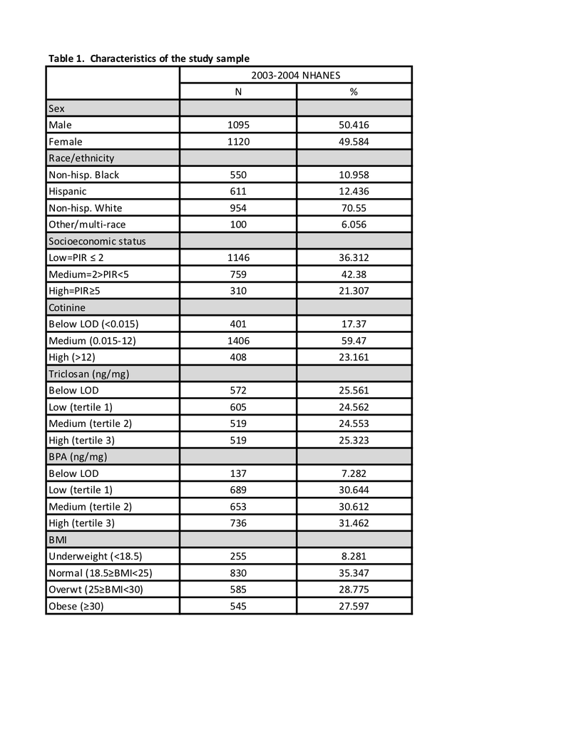

### Table 2

**Note: treat BMI as a continuous variable, use linear regression, be sure to use indicator variables where necessary**

| Observations | 2215 |
| --- | --- |
| Dependent variable | log(BMI) |
| Type | Survey-weighted linear regression |

| R² | 0.00 |
| --- | --- |
| Adj. R² | -156.75 |

|  | Est. | S.E. | t val. | p |
| --- | --- | --- | --- | --- |
| (Intercept) | 3.27 | 0.01 | 357.09 | 0.00 |
| Gender_Female | -0.02 | 0.02 | -1.38 | 0.19 |

Standard errors: Robust

| Observations | 2215 |
| --- | --- |
| Dependent variable | log(BMI) |
| Type | Survey-weighted linear regression |

| R² | 0.01 |
| --- | --- |
| Adj. R² | -181.19 |

|  | Est. | S.E. | t val. | p |
| --- | --- | --- | --- | --- |
| (Intercept) | 3.26 | 0.01 | 365.90 | 0.00 |
| Race_Eth_NH_Black | 0.04 | 0.01 | 3.16 | 0.01 |
| Race_Eth_Other | -0.09 | 0.02 | -3.97 | 0.00 |
| Race_Eth_Hispanic | -0.01 | 0.02 | -0.59 | 0.57 |

Standard errors: Robust

| Observations | 2215 |
| --- | --- |
| Dependent variable | log(BMI) |
| Type | Survey-weighted linear regression |

| R² | 0.01 |
| --- | --- |
| Adj. R² | -168.33 |

|  | Est. | S.E. | t val. | p |
| --- | --- | --- | --- | --- |
| (Intercept) | 3.23 | 0.01 | 263.02 | 0.00 |
| SES_Medium | 0.04 | 0.01 | 3.06 | 0.01 |
| SES_High | 0.04 | 0.02 | 2.30 | 0.04 |

Standard errors: Robust

| Observations | 2215 |
| --- | --- |
| Dependent variable | log(BMI) |
| Type | Survey-weighted linear regression |

| R² | 0.00 |
| --- | --- |
| Adj. R² | -168.92 |

|  | Est. | S.E. | t val. | p |
| --- | --- | --- | --- | --- |
| (Intercept) | 3.25 | 0.02 | 191.41 | 0.00 |
| Cot_Class_Medium | 0.00 | 0.02 | 0.09 | 0.93 |
| Cot_Class_High | 0.03 | 0.03 | 1.13 | 0.28 |

Standard errors: Robust

| Observations | 2215 |
| --- | --- |
| Dependent variable | log(BMI) |
| Type | Survey-weighted linear regression |

| R² | 0.00 |
| --- | --- |
| Adj. R² | -182.93 |

|  | Est. | S.E. | t val. | p |
| --- | --- | --- | --- | --- |
| (Intercept) | 3.24 | 0.01 | 243.70 | 0.00 |
| TriTert_Q2 | 0.04 | 0.02 | 2.05 | 0.06 |
| TriTert_Q3 | 0.03 | 0.02 | 1.71 | 0.11 |
| TriTert_Q4 | 0.02 | 0.02 | 1.38 | 0.19 |

Standard errors: Robust

| Observations | 2215 |
| --- | --- |
| Dependent variable | log(BMI) |
| Type | Survey-weighted linear regression |

| R² | 0.01 |
| --- | --- |
| Adj. R² | -181.52 |

|  | Est. | S.E. | t val. | p |
| --- | --- | --- | --- | --- |
| (Intercept) | 3.23 | 0.02 | 179.49 | 0.00 |
| BPATert_Q2 | 0.06 | 0.02 | 2.31 | 0.04 |
| BPATert_Q3 | 0.03 | 0.02 | 1.24 | 0.24 |
| BPATert_Q4 | -0.00 | 0.03 | -0.12 | 0.91 |

Standard errors: Robust

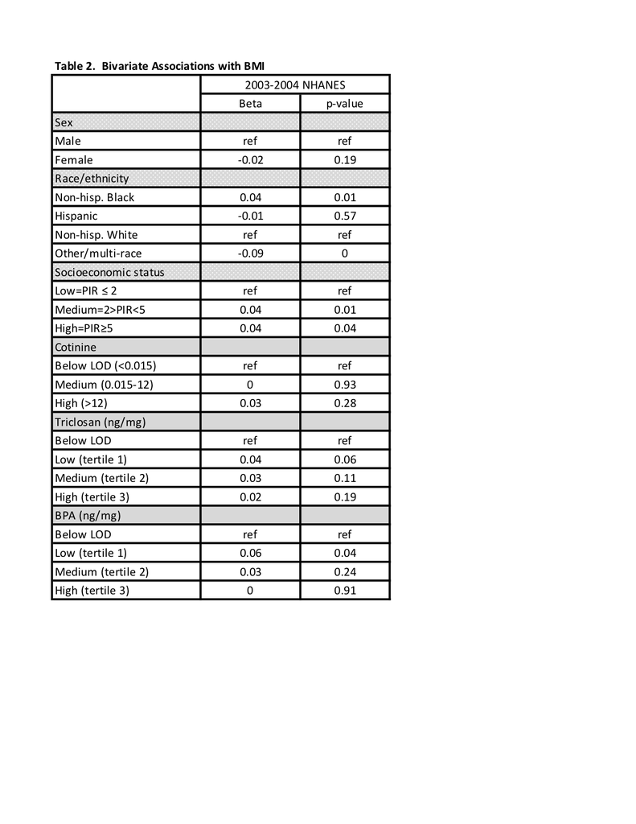

### Table 3

**To complete this table, you will need to run 3 models:**  
* Triclosan in 4 categories (a)  
* Triclosan categories as a continuous variable (b)  
* Triclosan in 2 categories (c)

**In each of the models, adjust for the following covariates:**  
* age (continuous)  
* race (using the categories in Table 2)  
* socioeconomic status (using PIR categories in Table 2)  
* cotinine (using categories in Table 2)

| Observations | 2215 |
| --- | --- |
| Dependent variable | log(BMI) |
| Type | Survey-weighted linear regression |

| R² | 0.17 |
| --- | --- |
| Adj. R² | -458.08 |

|  | Est. | S.E. | t val. | p |
| --- | --- | --- | --- | --- |
| (Intercept) | 2.99 | 0.02 | 124.82 | 0.00 |
| TriTert_Q2 | 0.06 | 0.02 | 3.34 | 0.03 |
| TriTert_Q3 | 0.04 | 0.01 | 2.94 | 0.04 |
| TriTert_Q4 | 0.03 | 0.01 | 2.39 | 0.07 |
| Age | 0.00 | 0.00 | 16.35 | 0.00 |
| Race_Eth_NH_Black | 0.07 | 0.01 | 5.14 | 0.01 |
| Race_Eth_Other | -0.07 | 0.02 | -3.12 | 0.04 |
| Race_Eth_Hispanic | 0.04 | 0.02 | 2.08 | 0.11 |
| SES_Medium | 0.02 | 0.01 | 2.40 | 0.07 |
| SES_High | 0.03 | 0.02 | 1.87 | 0.13 |
| Cot_Class_Medium | 0.03 | 0.02 | 1.09 | 0.34 |
| Cot_Class_High | 0.04 | 0.03 | 1.64 | 0.18 |

Standard errors: Robust

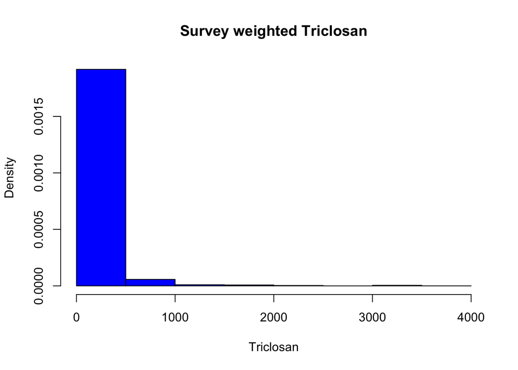

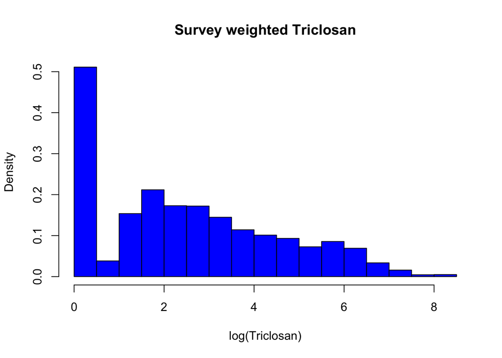

```
##
## Call:
## svyglm(formula = log(BMI) ~ log(Tri_Adj) + Age + Race_Eth_NH_Black +
##     Race_Eth_Other + Race_Eth_Hispanic + SES_Medium + SES_High +
##     Cot_Class_Medium + Cot_Class_High, design = NHANES_dum.svy)
##
## Survey design:
## svydesign(ids = ~SampUnit, strata = ~Strata, weights = ~Weight,
##     nest = T, data = NHANES_dum)
##
## Coefficients:
##                    Estimate Std. Error t value Pr(>|t|)
## (Intercept)        3.019646   0.023974 125.955 1.69e-11 ***
## log(Tri_Adj)      -0.002134   0.001922  -1.110  0.30941
## Age                0.004608   0.000302  15.258 5.00e-06 ***
## Race_Eth_NH_Black  0.079287   0.014128   5.612  0.00137 **
## Race_Eth_Other    -0.071474   0.023209  -3.080  0.02167 *
## Race_Eth_Hispanic  0.037416   0.018998   1.969  0.09643 .
## SES_Medium         0.025177   0.010183   2.472  0.04830 *
## SES_High           0.029703   0.016225   1.831  0.11688
## Cot_Class_Medium   0.027897   0.023248   1.200  0.27539
## Cot_Class_High     0.042685   0.025293   1.688  0.14245
## ---
## Signif. codes:  0 '***' 0.001 '**' 0.01 '*' 0.05 '.' 0.1 ' ' 1
##
## (Dispersion parameter for gaussian family taken to be 0.04838292)
##
## Number of Fisher Scoring iterations: 2
```

```
##
## Call:
## svyglm(formula = log(BMI) ~ TriComment_Above_LOD + Age + Race_Eth_NH_Black +
##     Race_Eth_Other + Race_Eth_Hispanic + SES_Medium + SES_High +
##     Cot_Class_Medium + Cot_Class_High, design = NHANES_dum.svy)
##
## Survey design:
## svydesign(ids = ~SampUnit, strata = ~Strata, weights = ~Weight,
##     nest = T, data = NHANES_dum)
##
## Coefficients:
##                       Estimate Std. Error t value Pr(>|t|)
## (Intercept)           2.990558   0.023927 124.986 1.77e-11 ***
## TriComment_Above_LOD  0.042206   0.012143   3.476  0.01321 *
## Age                   0.004687   0.000285  16.442 3.23e-06 ***
## Race_Eth_NH_Black     0.075315   0.013751   5.477  0.00155 **
## Race_Eth_Other       -0.071284   0.023541  -3.028  0.02315 *
## Race_Eth_Hispanic     0.038478   0.019007   2.024  0.08935 .
## SES_Medium            0.022782   0.010190   2.236  0.06674 .
## SES_High              0.027179   0.015880   1.711  0.13783
## Cot_Class_Medium      0.028662   0.023039   1.244  0.25988
## Cot_Class_High        0.044187   0.025442   1.737  0.13310
## ---
## Signif. codes:  0 '***' 0.001 '**' 0.01 '*' 0.05 '.' 0.1 ' ' 1
##
## (Dispersion parameter for gaussian family taken to be 0.04806448)
##
## Number of Fisher Scoring iterations: 2
```

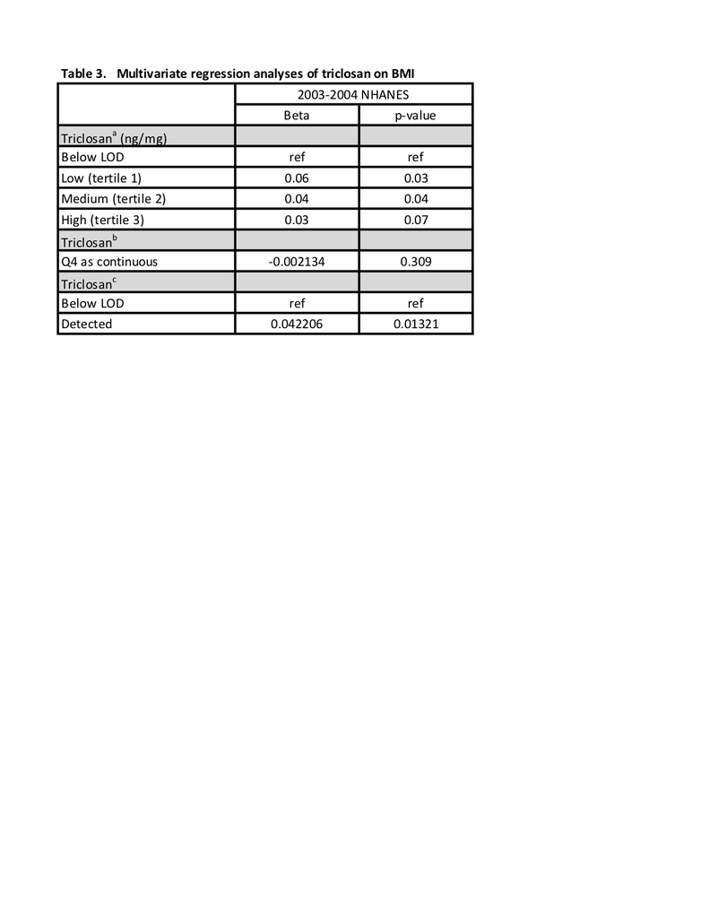

## Step 4: Graphic representation of results

Make a graph that summarizes your results (whatever format you like; be sure to label all axes).

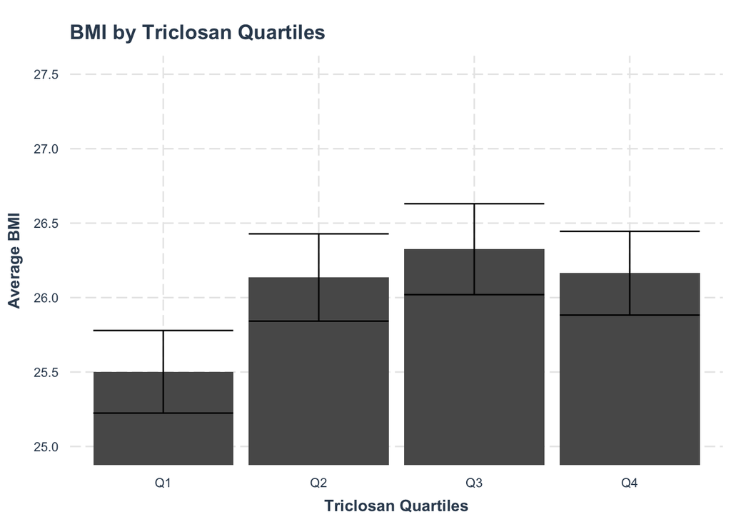

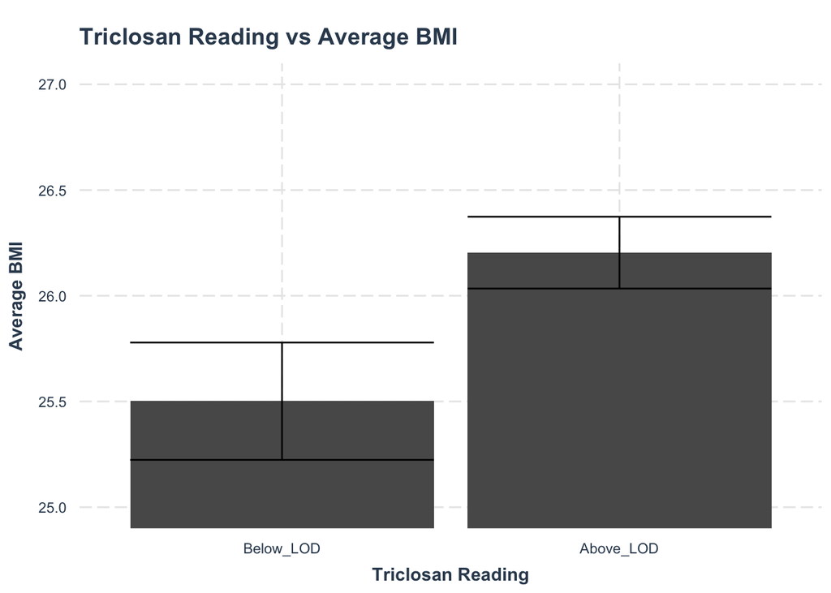

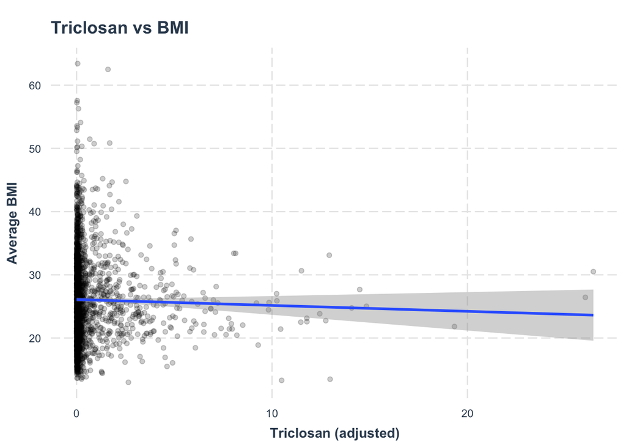

## Step 5: Interpretation

Describe your results using the guidelines below (please be as concise as possible using complete sentences rather than bullets or fragments, etc.)

### Hypothesis:

**Triclosan exposure is associated with an increase in BMI.**

### Sample:

**Data was taken from the 2003-2004 NHANES database. The original dataset included 10122 observations. Observations missing any variable were excluded, leaving a final sample size of 2215.**

### Results:

**When subjects are split into two groups based on whether their Triclosan levels are above or below the Limit of Detection, Triclosan exposure is associated with significantly higher BMI (Beta = 0.042206, p = 0.01321). When Triclosan exposure is split into four quartiles, Low and Medium Triclosan exposure are associated with significant increases in BMI (Beta = 0.06, p = 0.03 and Beta = 0.04, p = 0.04 respectively). However, High Triclosan exposure is not associated with a significant change in BMI (p = 0.07). Since the largest effect is seen in Low exposures, and no significant effect is seen at high exposures, there is not evidence of a dose-repsonse effect. When Triclosan exposure and BMI are both interpreted as continuous variables, no significant association is found between the two (p = 0.309).**